# Lab 04 - La Quinta is Spanish for next to Denny’s, Pt. 1

Naida Torres

2023-10-11

### Load packages and data

Starter code wanted to load dsbox, however, there is no version of that package for the latest version of R.

```r
library(tidyverse)
library(here)
```

I found the states.csv in the DSBox GitHub by searching states.csv in the search repository function.

```r
thisfile = here("data", "states.csv")
states = read_csv(thisfile)
thisfile = here("data_raw", "dennys.csv")
dennys = read_csv(thisfile)
thisfile = here("data_raw", "laquinta.csv")
laquinta = read_csv(thisfile)
```

### Exercise 1

What are the dimensions of the Denny’s dataset? (Hint: Use inline R code and functions like nrow and ncol to compose your answer.) What does each row in the dataset represent? What are the variables?

The dimensions of the Denny’s dataset is 1643 by 6. Which means that there are 1643 rows which 6 columns. Each row in the dataset represents one Denny’s location. The variables include address, city, state, zip, longitude, and latitude.

```r
nrow(dennys)
```

```
[1] 1643
```

```r
ncol(dennys)
```

```
[1] 6
```

### Exercise 2

What are the dimensions of the La Quinta’s dataset? What does each row in the dataset represent? What are the variables?

```r
nrow(laquinta)
```

```
[1] 909
```

```r
ncol(laquinta)
```

```
[1] 6
```

Are there any La Quinta’s locations outside of the US? If so, which countries? What about Denny’s?

According to the website that the data came from, there are some La Quinta’s locations outside of the US. There are locations in Canada, Mexico, China, New Zealand, Turkey, United Arab Emirates, Chile, Colombia, and Ecuador. According to the website that the data came from, there are no Denny’s locations outside of the US.

### Exercise 4

Now take a look at the data. What would be some ways of determining whether or not either establishment has any locations outside the US using just the data (and not the websites). Don’t worry about whether you know how to implement this, just brainstorm some ideas. Write down at least one as your answer, but you’re welcomed to write down a few options too.

Both datasets have address, state, city, and zip, which can be cross referenced to check if they are within US bounds, or even using the longitude and latitude to do that. We could use states.csv and the state column in the datasets and check if the states.csv has the states abbreviation, then we know it is in the US since we are under the assumption that the states.csv is only including states within the US.

### Exercise 5

Find the Denny’s locations that are outside the US, if any. To do so, filter the Denny’s locations for observations where state is not in states$abbreviation. Note that the %in% operator matches the states listed in the state variable to those listed in states$abbreviation. The ! operator means not. Are there any Denny’s locations outside the US?

There are no Denny’s locations outside the US.

```r
dennys_notinUS = dennys %>%
  filter(!(state %in% states$abbreviation))
```

### Exercise 6

Add a country variable to the Denny’s dataset and set all observations equal to “United States”. Remember, you can use the mutate function for adding a variable. Make sure to save the result of this as dennys again so that the stored data frame contains the new variable going forward.

```r
dennys_inUS = dennys %>%
  mutate(country = "United States")
dennys = dennys %>%
  mutate(country = "United States")
```

### Exercise 7

Find the La Quinta locations that are outside the US, and figure out which country they are in. This might require some googling. Take notes, you will need to use this information in the next exercise.

```r
laquinta_notinUS = laquinta %>%
  filter(!(state %in% states$abbreviation))
```

### Exercise 8

Add a country variable to the La Quinta dataset. Use the case_when function to populate this variable. You’ll need to refer to your notes from Exercise 7 about which country the non-US locations are in.

```r
mexico_states = c("QR", "CH", "NL", "VE", "PU", "SL", "AG")
laquinta = laquinta %>%
  mutate(country = case_when(
    state %in% states$abbreviation ~ "United States",
    state %in% c("ON", "BC") ~ "Canada",
    state == "ANT" ~ "Colombia",
    state %in% mexico_states ~ "Mexico",
    state == "FM" ~ "Honduras"
))
```

Going forward we will work with the data from the United States only. All Denny’s locations are in the United States, so we don’t need to worry about them. However we do need to filter the La Quinta dataset for locations in United States.

```r
laquinta <- laquinta %>%
  filter(country == "United States")
```

### Exercise 9

Which states have the most and fewest Denny’s locations? What about La Quinta? Is this surprising? Why or why not?

States that have the most Denny’s locations include California, Texas, and Florida. States that have the fewest Denny’s locations include Delaware, Vermont, and Alaska, omitting District of Columbia. States that have the most LaQuinta locations include Texas, Florida, and California. States that have the fewest LaQuinta locations include Maine, Alaska, New Hampshire. These results do not include states that do not have any locations. These results are not very surprising, considering that businesses make their location decisions based on how large a state is, if they have any major cities, and general want for a location in said location.

Most Locations:

```r
dennys %>%
  count(state) %>%
  inner_join(states, by = c("state" = "abbreviation")) %>%
  arrange(desc(n))
```

| state | n | name | area |
| --- | --- | --- | --- |
| CA | 403 | California | 163694.74 |
| TX | 200 | Texas | 268596.46 |
| FL | 140 | Florida | 65757.70 |
| AZ | 83 | Arizona | 113990.30 |
| IL | 56 | Illinois | 57913.55 |
| NY | 56 | New York | 54554.98 |
| WA | 49 | Washington | 71297.95 |
| OH | 44 | Ohio | 44825.58 |
| MO | 42 | Missouri | 69706.99 |
| PA | 40 | Pennsylvania | 46054.35 |

[output cut: 41 more lines]

```r
laquinta %>%
  count(state) %>%
  inner_join(states, by = c("state" = "abbreviation")) %>%
  arrange(desc(n))
```

| state | n | name | area |
| --- | --- | --- | --- |
| TX | 237 | Texas | 268596.46 |
| FL | 74 | Florida | 65757.70 |
| CA | 56 | California | 163694.74 |
| GA | 41 | Georgia | 59425.15 |
| TN | 30 | Tennessee | 42144.25 |
| OK | 29 | Oklahoma | 69898.87 |
| LA | 28 | Louisiana | 52378.13 |
| CO | 27 | Colorado | 104093.67 |
| NM | 19 | New Mexico | 121590.30 |
| NY | 19 | New York | 54554.98 |

[output cut: 38 more lines]

Fewest Locations:

```r
dennys %>%
  count(state) %>%
  inner_join(states, by = c("state" = "abbreviation")) %>%
  arrange(n)
```

| state | n | name | area |
| --- | --- | --- | --- |
| DE | 1 | Delaware | 2488.72 |
| DC | 2 | District of Columbia | 68.34 |
| VT | 2 | Vermont | 9616.36 |
| AK | 3 | Alaska | 665384.04 |
| IA | 3 | Iowa | 56272.81 |
| NH | 3 | New Hampshire | 9349.16 |
| SD | 3 | South Dakota | 77115.68 |
| WV | 3 | West Virginia | 24230.04 |
| LA | 4 | Louisiana | 52378.13 |
| MT | 4 | Montana | 147039.71 |

[output cut: 41 more lines]

```r
laquinta %>%
  count(state) %>%
  inner_join(states, by = c("state" = "abbreviation")) %>%
  arrange(n)
```

| state | n | name | area |
| --- | --- | --- | --- |
| ME | 1 | Maine | 35379.74 |
| AK | 2 | Alaska | 665384.04 |
| NH | 2 | New Hampshire | 9349.16 |
| RI | 2 | Rhode Island | 1544.89 |
| SD | 2 | South Dakota | 77115.68 |
| VT | 2 | Vermont | 9616.36 |
| WV | 3 | West Virginia | 24230.04 |
| WY | 3 | Wyoming | 97813.01 |
| IA | 4 | Iowa | 56272.81 |
| MI | 4 | Michigan | 96713.51 |

[output cut: 38 more lines]

### Exercise 10

Which states have the most Denny’s locations per thousand square miles? What about La Quinta?

I have made the decision to omit DC from this specific question, since it is a high outlier, and is not even considered a state.

States that have the most Denny’s locations per thousand square miles include Rhode Island, California, and Connecticut. States that have the most LaQuinta locations per thousand square miles include Rhode Island, Florida, and Connecticut.

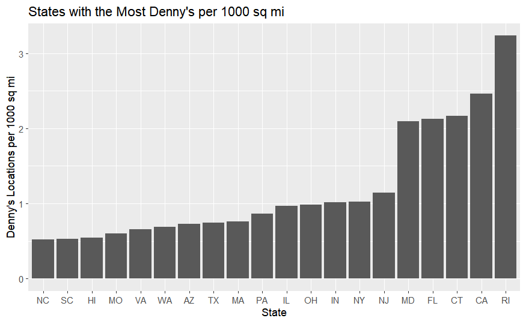

```r
dennys_conc = dennys %>%
  count(state) %>%
  inner_join(states,
             by = c("state" = "abbreviation")) %>%
  mutate(loc_1000sqmi = n / area * 1000)

laquinta_conc = laquinta %>%
  count(state) %>%
  inner_join(states,
             by = c("state" = "abbreviation")) %>%
  mutate(loc_1000sqmi = n / area * 1000)

dennys_conc %>%
  filter(loc_1000sqmi > .5, state != "DC") %>%
  ggplot(aes(x = reorder(state, loc_1000sqmi))) +
  geom_bar(aes(weight = loc_1000sqmi)) +
  ggtitle("States with the Most Denny's per 1000 sq mi") +
  xlab("State") +
  ylab("Denny's Locations per 1000 sq mi")
```

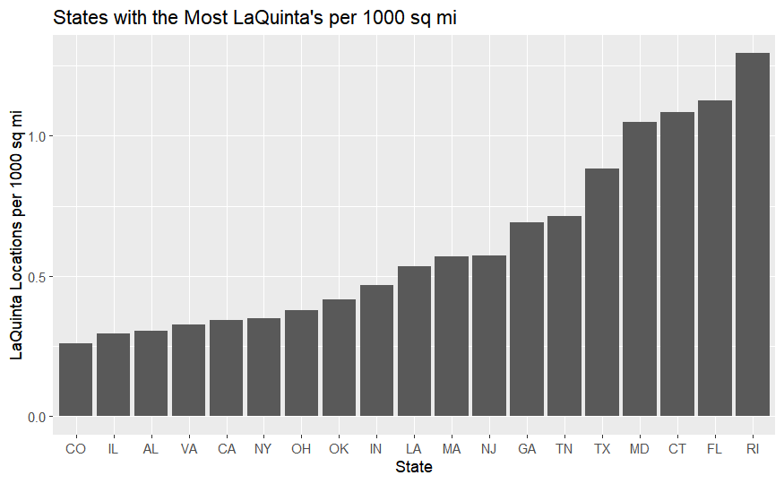

```r
laquinta_conc %>%
  filter(loc_1000sqmi > .25) %>%
  ggplot(aes(x = reorder(state, loc_1000sqmi))) +
  geom_bar(aes(weight = loc_1000sqmi)) +
  ggtitle("States with the Most LaQuinta's per 1000 sq mi") +
  xlab("State") +
  ylab("LaQuinta Locations per 1000 sq mi")
```

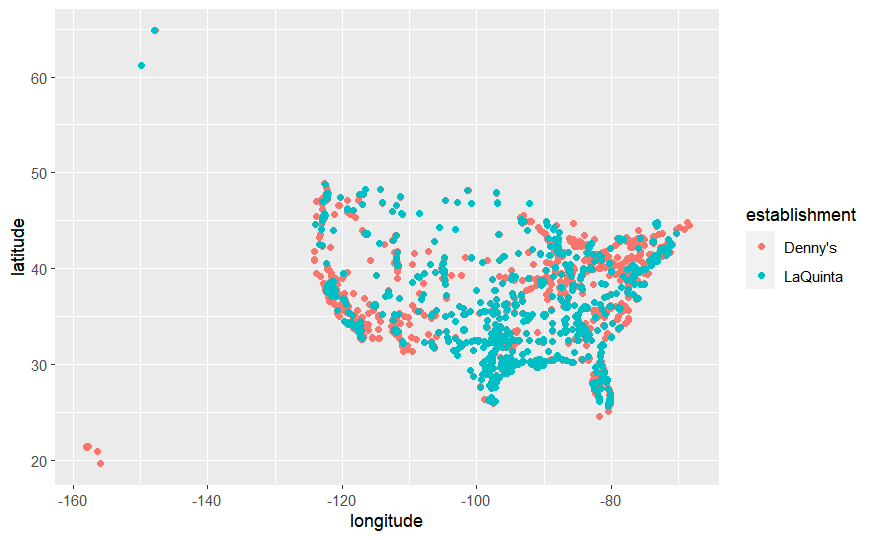

```r
dennys <- dennys %>%
  mutate(establishment = "Denny's")
laquinta <- laquinta %>%
  mutate(establishment = "LaQuinta")
dennys_laquinta <- bind_rows(dennys, laquinta)
ggplot(dennys_laquinta,
       mapping = aes(x = longitude,
                     y = latitude,
                     color = establishment)) +
  geom_point()
```

### Exercise 11

Filter the data for observations in North Carolina only, and recreate the plot. You should also adjust the transparency of the points, by setting the alpha level, so that it’s easier to see the overplotted ones. Visually, does Mitch Hedberg’s joke appear to hold here?

The joke appears to hold here, however, it does not hold for the opposite. If you see a LaQuinta, you will likely see a Denny’s nearby, but not vice versa.

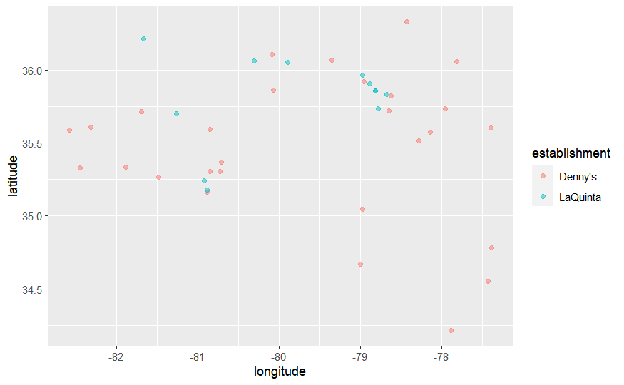

```r
dennys_laquinta_NC = dennys_laquinta %>%
  filter(state == "NC")
dennys_laquinta_NC %>%
  ggplot(aes(x = longitude,
             y = latitude,
             color = establishment)) +
  geom_point(alpha = .5)
```

### Exercise 12

Now filter the data for observations in Texas only, and recreate the plot, with an appropriate alpha level. Visually, does Mitch Hedberg’s joke appear to hold here?

The joke appears to not hold here, since there seems to be a larger amount of LaQuinta’s in Texas.

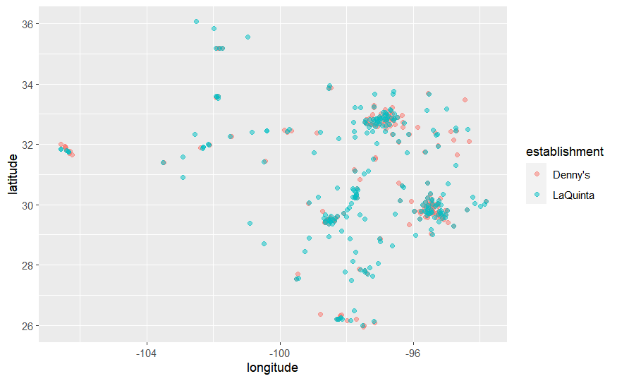

```r
dennys_laquinta_TX = dennys_laquinta %>%
  filter(state == "TX")
dennys_laquinta_TX %>%
  ggplot(aes(x = longitude,
             y = latitude,
             color = establishment)) +
  geom_point(alpha = .5)
```